# Linear Regression

2018204094 박형빈

# 1 Import Data

**소비자 데이터 기반 소비 예측 경진대회**의 데이터셋(purchase.csv)을 활용, Linear Regression model을 구축하여 소비자 데이터를 바탕으로 **고객의 제품 총 소비량을 예측**하였다.

```r
# 현재 경로를 받아서 dataset을 불러옵니다
wd <- getwd()
setwd(wd)
rm(wd)

purchase <- read.csv('purchase.csv', header= T, na.strings = c("", " ", NA)) # 결측치를 받아옵니다
head(purchase)
```

```
##   id Year_Birth  Education Marital_Status Income Kidhome Teenhome Recency
## 1  0       1974     Master       Together  46014       1        1      21
## 2  1       1962 Graduation         Single  76624       0        1      68
## 3  2       1951 Graduation        Married  75903       0        1      50
## 4  3       1974      Basic        Married  18393       1        0       2
## 5  4       1946        PhD       Together  64014       2        1      56
## 6  5       1952 Graduation         Single  47958       0        1       8
##   NumDealsPurchases NumWebPurchases NumCatalogPurchases NumStorePurchases
## 1                10               7                   1                 8
## 2                 1               5                  10                 7
## 3                 2               6                   6                 9
## 4                 2               3                   0                 3
## 5                 7               8                   2                 5
## 6                 2               6                   3                 5
##   NumWebVisitsMonth AcceptedCmp3 AcceptedCmp4 AcceptedCmp5 AcceptedCmp1
## 1                 7            0            0            0            0
## 2                 1            1            0            0            0
## 3                 3            0            0            0            0
## 4                 8            0            0            0            0
## 5                 7            0            0            0            1
## 6                 5            0            0            0            0
##   AcceptedCmp2 Complain Response target day month year
## 1            0        0        0    541  21     1 2013
## 2            0        0        0    899  24     5 2014
## 3            0        0        0    901   8     4 2013
## 4            0        0        0     50  29     3 2014
## 5            0        0        0    444  10     6 2014
## 6            0        0        0    407  19     1 2013
```

# 2 EDA

소비자 데이터(perchase)의 전체적인 EDA 결과 요약은 다음과 같이 정리할 수 있다.  
구체적인 EDA 과정은 코드와 주석을 통해 확인할 수 있다.

**1,108 rows X 24 cols**

**X variables**

- feature column
  - id
    - 식별자 정보는 학습에 유의하지 않으므로 제거할 예정
- Categorical 범주형 (실수형이 아닌)
  - Education : 학력 (5)
  - Marital_status : 고객 결혼 상태 (8)
  - AcceptedCmp1: 고객이 첫 번째 캠페인에서 제안을 수락(1)/비수락(0)
  - AcceptedCmp2: 고객이 두 번째 캠페인에서 제안을 수락(1)/비수락(0)
  - AcceptedCmp3: 고객이 세 번째 캠페인에서 제안을 수락(1)/비수락(0)
  - AcceptedCmp1: 고객이 네 번째 캠페인에서 제안을 수락(1)/비수락(0)
  - AcceptedCmp1: 고객이 다섯 번째 캠페인에서 제안을 수락(1)/비수락(0)
  - Complain : 고객이 지난 2년 동안 불만을 제기한 경우(1)/(0)
  - Response : 고객이 마지막 캠페인에서 제안을 수락(1)/비수락(0)
- Numerical 연속형 (실수형인)
  - Year_Birth : 고객생년월일
  - Income : 고객 연간 가구 소득
  - Kidhome : 고객 가구의 자녀 수
  - Teenhome : 고객 가구의 청소년 수
  - year : 고객이 회사에 등록한 날짜, 년
  - month : 고객이 회사에 등록한 날짜, 월
  - day : 고객이 회사에 등록한 날짜, 일
  - Recency : 고객의 마지막 구매 이후 일수
  - NumDealsPurchases : 할인된 구매 횟수
  - NumWebPurchases : 회사 웹사이트를 통한 구매 건수
  - NumCatalogPurchases : 카탈로그를 사용한 구매 수
  - NumStorePuchases : 매장에서 직접 구매한 횟수
  - NumWebVisitsMonth : 지난 달 회사 웹사이트 방문 횟수

**y variable**

- target : 고객의 제품 총 소비량

```r
# 데이터의 기본 구조를 확인합니다
str(purchase)
```

```
## 'data.frame':    1108 obs. of  24 variables:
##  $ id                 : int  0 1 2 3 4 5 6 7 8 9 ...
##  $ Year_Birth         : int  1974 1962 1951 1974 1946 1952 1971 1978 1968 1952 ...
##  $ Education          : chr  "Master" "Graduation" "Graduation" "Basic" ...
##  $ Marital_Status     : chr  "Together" "Single" "Married" "Married" ...
##  $ Income             : int  46014 76624 75903 18393 64014 47958 22804 54162 45688 61823 ...
##  $ Kidhome            : int  1 0 0 1 2 0 1 1 0 0 ...
##  $ Teenhome           : int  1 1 1 0 1 1 0 1 1 1 ...
##  $ Recency            : int  21 68 50 2 56 8 75 31 20 26 ...
##  $ NumDealsPurchases  : int  10 1 2 2 7 2 1 1 2 4 ...
##  $ NumWebPurchases    : int  7 5 6 3 8 6 2 1 3 8 ...
##  $ NumCatalogPurchases: int  1 10 6 0 2 3 0 0 1 2 ...
##  $ NumStorePurchases  : int  8 7 9 3 5 5 2 3 8 10 ...
##  $ NumWebVisitsMonth  : int  7 1 3 8 7 5 9 4 4 7 ...
##  $ AcceptedCmp3       : int  0 1 0 0 0 0 0 0 0 0 ...
##  $ AcceptedCmp4       : int  0 0 0 0 0 0 0 0 1 0 ...
##  $ AcceptedCmp5       : int  0 0 0 0 0 0 0 0 0 0 ...
##  $ AcceptedCmp1       : int  0 0 0 0 1 0 0 0 0 0 ...
##  $ AcceptedCmp2       : int  0 0 0 0 0 0 0 0 0 0 ...
##  $ Complain           : int  0 0 0 0 0 0 0 0 0 0 ...
##  $ Response           : int  0 0 0 0 0 0 0 0 0 0 ...
##  $ target             : int  541 899 901 50 444 407 26 42 306 884 ...
##  $ day                : int  21 24 8 29 10 19 31 18 25 18 ...
##  $ month              : int  1 5 4 3 6 1 7 3 1 2 ...
##  $ year               : int  2013 2014 2013 2014 2014 2013 2013 2013 2014 2013 ...
```

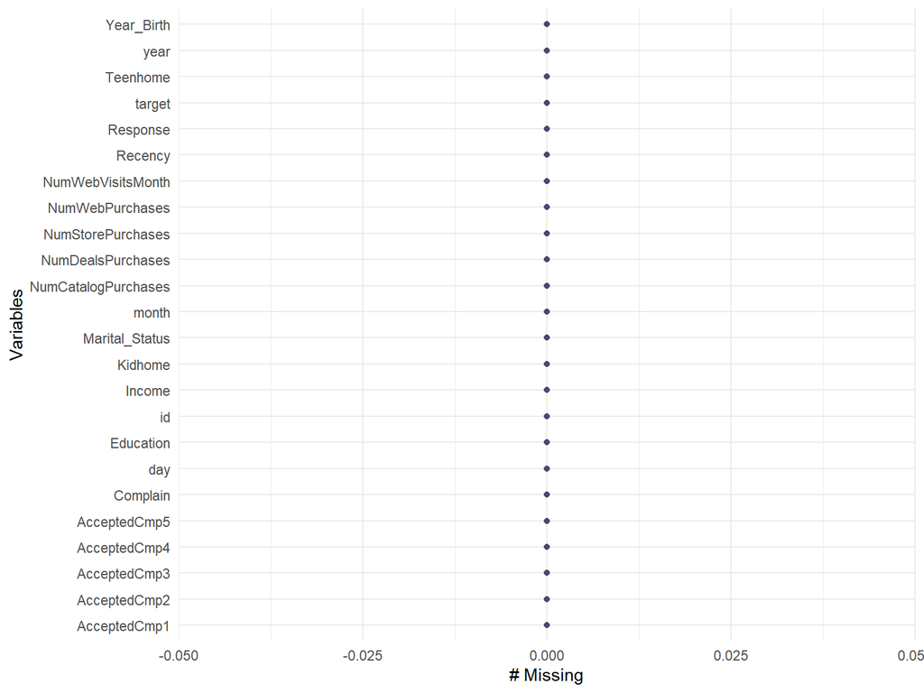

```r
# 전체 결측치 비율을 확인합니다
# 해당 데이터에는 결측치가 존재하지 않습니다
naniar::gg_miss_var(purchase)
```

```r
# 범주형 변수, 연속형 변수 각각을 확인하기 위해 data를 나누어서 EDA를 진행합니다
# y 변수인 target은 num_data에 넣어서 임의로 진행합니다
cat_data <- purchase[, c(3, 4, 14, 15, 16, 17, 18, 19, 20)]
num_data <- purchase[, c(2, 5, 6, 7, 8, 9, 10, 11, 12, 13, 21, 22, 23, 24)]
```

범주형 변수, 연속형 변수로 나누어서 EDA를 진행하였다.

[output not shown]

```
## [1] "Education  5"
```

```
## [1] "Marital_Status  8"
```

```
## [1] "AcceptedCmp1  2"
```

```
## [1] "AcceptedCmp2  2"
```

```
## [1] "AcceptedCmp3  2"
```

```
## [1] "AcceptedCmp4  2"
```

```
## [1] "AcceptedCmp5  2"
```

```
## [1] "Complain  2"
```

```
## [1] "Response  2"
```

education(학력)을 제외한 나머지 변수들은 모두 순서성이 없는 Nominal 변수이다.  
education variable은 순서가 있는 Ordinary 변수로 “Basic < Graduation < 2n Cycle < Master < phD”(dataset discription 참고)의 순서를 가지고 있다.  
다행히도 education, marital 변수를 제외한 나머지 변수들은 0 or 1의 label로 이루어져 있기 때문에 특별한 전처리가 필요하지 않다. 즉, education, marital 범주형 변수에 대해서만 전처리를 진행하면 된다.

```r
# Plotting을 위한 간단한 전처리
# 데이터 분석시, 범주형 변수에 대해서 factor타입으로 변환 후 모델을 구축해야 합니다
cat_data$Marital_Status <- factor(cat_data$Marital_Status)
cat_data$Education <- factor(cat_data$Education, levels = c("Basic", "Graduation", "2n Cycle", "Master", "PhD"))
```

범주형 변수들을 Bar plot을 통해 시각화 하여 각각이 가지는 분포에 대한 특징을 확인하였다. Graph를 모두 확인하였지만 보고서의 분량을 감안하여 특정 변수에 대해서만 짧은 추론과 주석을 함께 작성하였다.

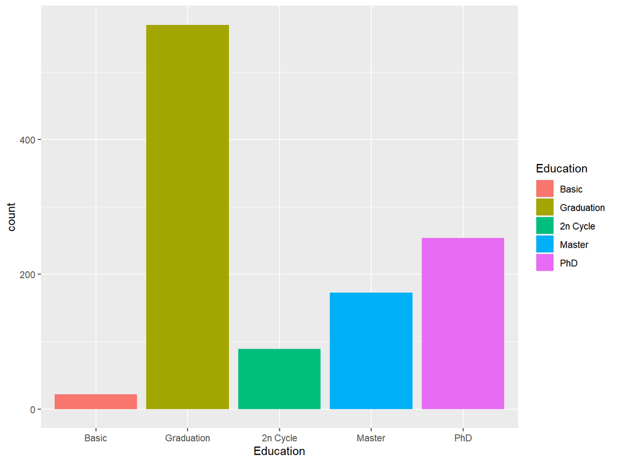

```r
# 학력은 Graduation의 분포가 가장 많으며 그 이후로는 점점 증가하는 추세로 많습니다
cat_data %>% ggplot(aes(x=Education, fill = Education)) + geom_bar()
```

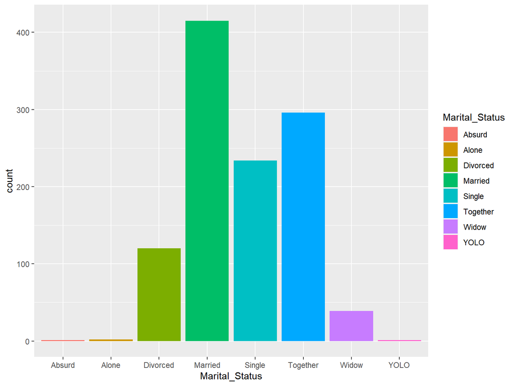

```r
# 결혼 상태는 혼인(Married)가 가장 많으며 그 다음으로 Together, Single이 많습니다
# Absurd, Alone, YOLO는 매우 적은 분포를 보이며
# 이로부터 해당 데이터셋을 제공한 판매처는 주로 가족 단위의 물건을 파는 곳이라고 추측됩니다
cat_data %>% ggplot(aes(x=Marital_Status, fill = Marital_Status)) + geom_bar()
```

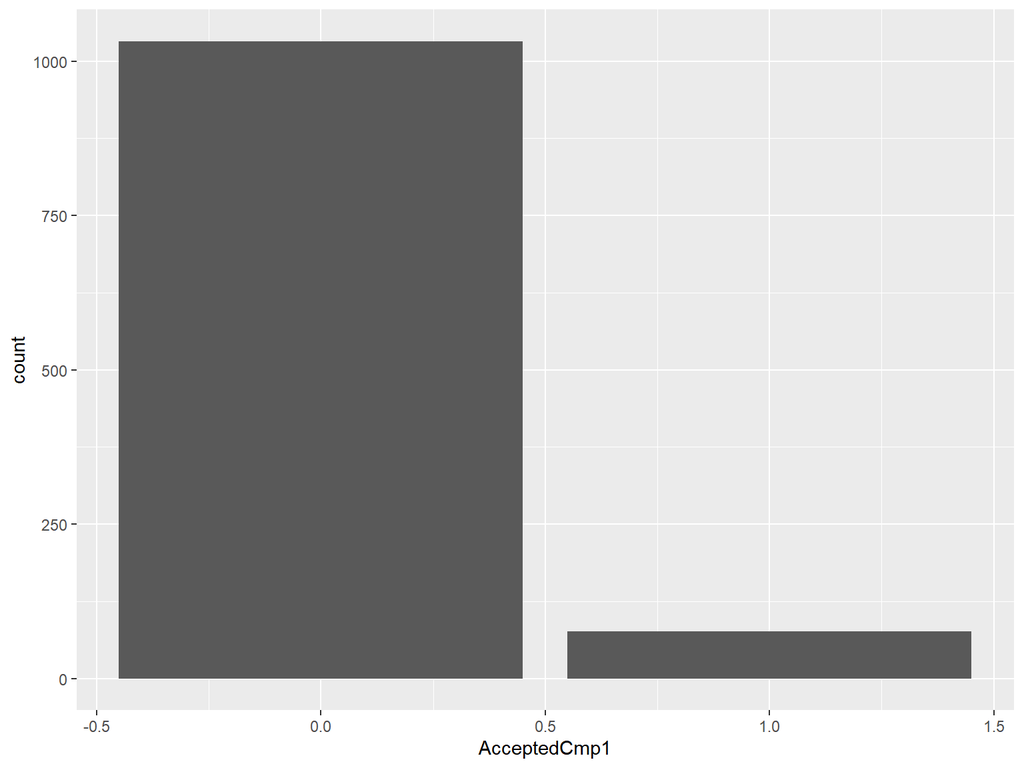

```r
# 모든 캠페인 제안과 불만 제기에 대해서 1보다는 0의 값이 많습니다
# 캠페인 제안을 수락한 건수도 적고 불만을 제기한 건수도 적다는 의미가 됩니다
# 오히려 수락할 경우 target에 많은 영향을 줄 수도 있을 것 같습니다
cat_data %>% ggplot(aes(x=AcceptedCmp1, fill = AcceptedCmp1)) + geom_bar()
```

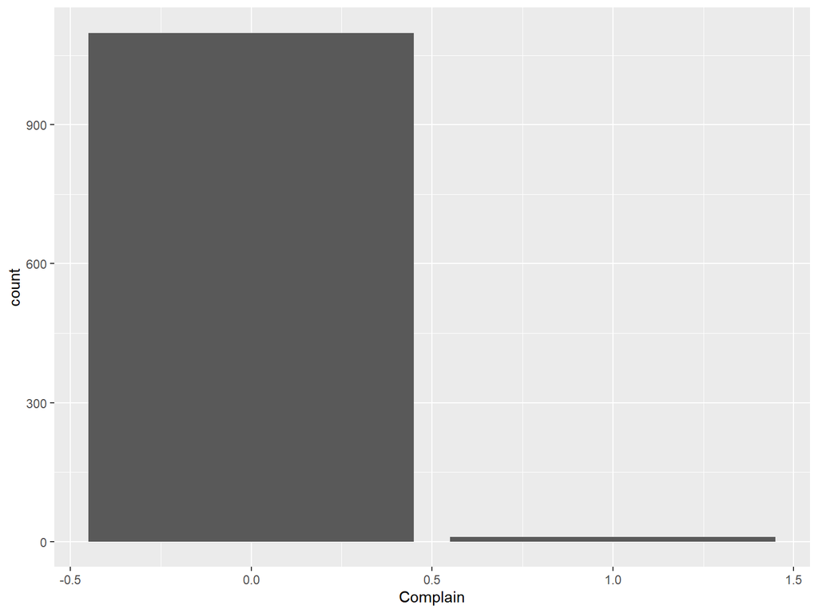

```r
cat_data %>% ggplot(aes(x=Complain, fill = Complain)) + geom_bar()
```

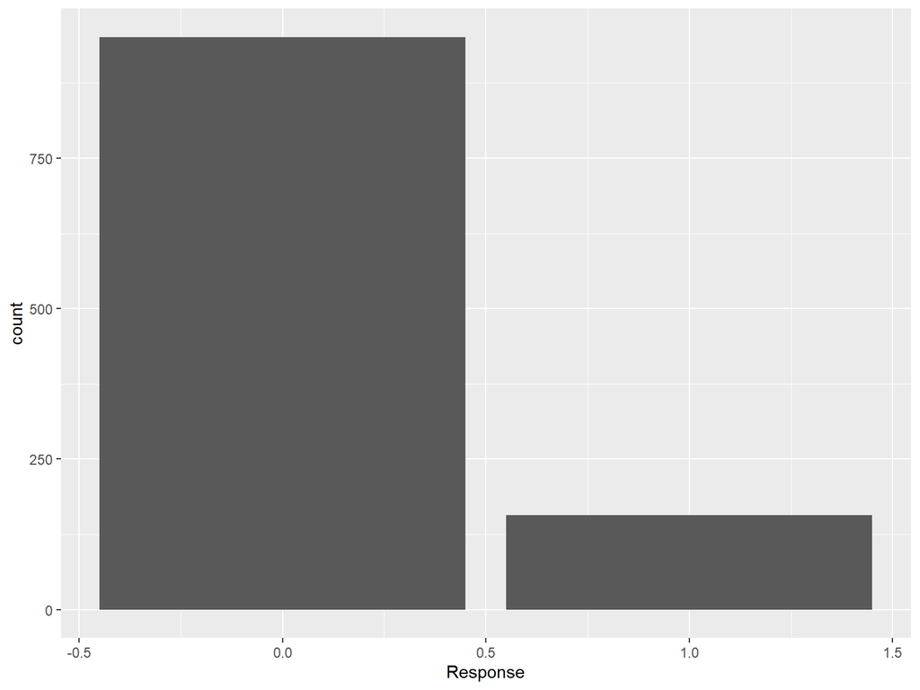

```r
cat_data %>% ggplot(aes(x=Response, fill = Response)) + geom_bar()
```

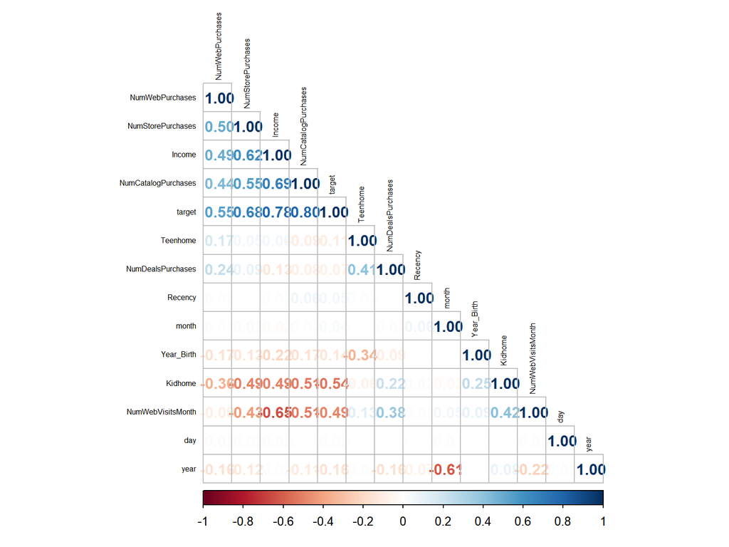

```r
# Numerical Variable EDA
# Correlation matrix
num_corr <- cor(num_data, method="pearson")
  corrplot(num_corr,method="number",type="lower",order="hclust",tl.cex=.5, tl.col='black')
```

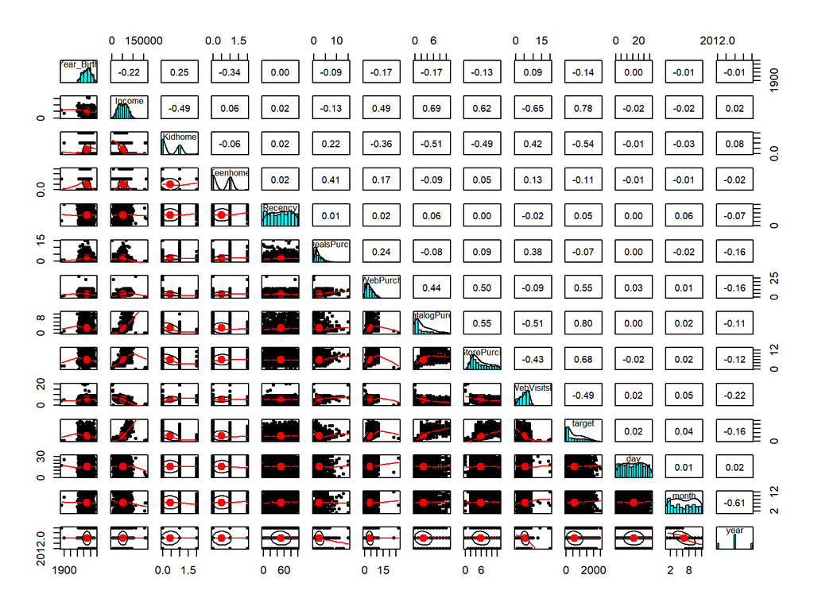

```r
# Histogram, Correlation, Scatter plot
pairs.panels(num_data)
```

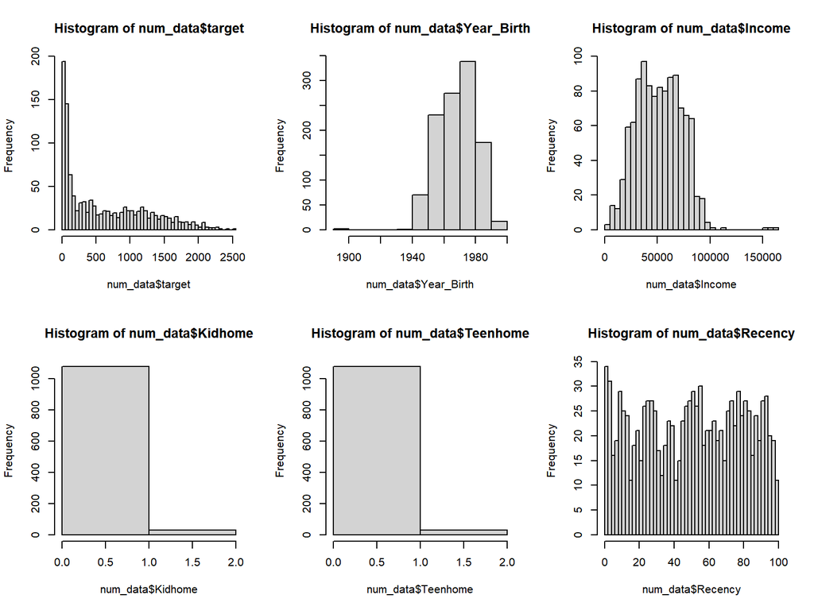

```r
# more detailed Histogram
par(mfrow=c(2,3))
hist(num_data$target, breaks=50)
hist(num_data$Year_Birth, breaks=10)
hist(num_data$Income, breaks=50)
hist(num_data$Kidhome, breaks=2)
hist(num_data$Teenhome, breaks=2)
hist(num_data$Recency, breaks=50)
```

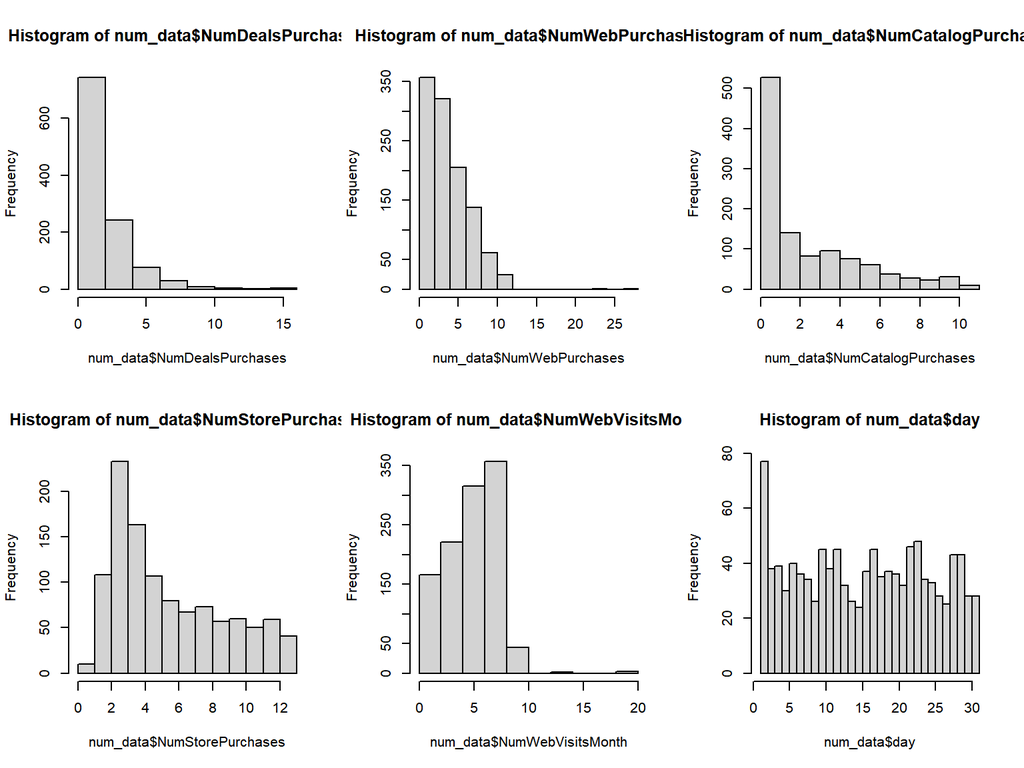

```r
hist(num_data$NumDealsPurchases, breaks=10)
hist(num_data$NumWebPurchases, breaks=10)
hist(num_data$NumCatalogPurchases, breaks=10)
hist(num_data$NumStorePurchases, breaks=10)
hist(num_data$NumWebVisitsMonth, breaks=10)
hist(num_data$day, breaks=30)
```

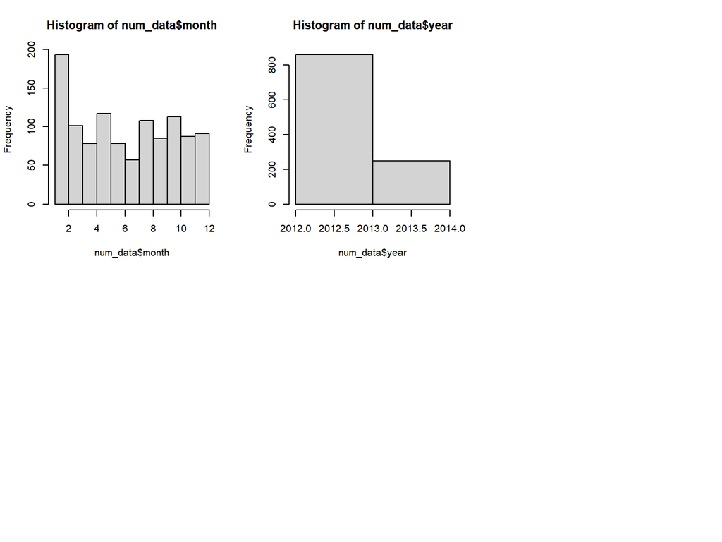

```r
hist(num_data$month, breaks=11)
hist(num_data$year, breaks=2)
```

```r
describe(num_data)
```

```
## Description of num_data
```

```
##
##  Numeric
##                         mean  median          var       sd valid.n
## Year_Birth           1968.70  1970.0       149.46    12.23    1108
## Income              52075.81 51609.5 454120080.51 21310.09    1108
## Kidhome                 0.43     0.0         0.30     0.55    1108
## Teenhome                0.51     0.0         0.30     0.55    1108
## Recency                50.16    51.0       845.97    29.09    1108
## NumDealsPurchases       2.34     2.0         3.78     1.94    1108
## NumWebPurchases         4.18     4.0         7.90     2.81    1108
## NumCatalogPurchases     2.69     2.0         7.80     2.79    1108
## NumStorePurchases       5.91     5.0        10.94     3.31    1108
## NumWebVisitsMonth       5.35     6.0         5.78     2.41    1108
## target                617.12   412.0    364318.44   603.59    1108
## day                    15.78    16.0        79.20     8.90    1108
## month                   6.46     6.0        12.31     3.51    1108
## year                 2013.00  2013.0         0.45     0.67    1108
```

차례대로 correlation matrix, scatter plot, histogram(bar plot)을 사용하여 연속형 변수의 분포와 상관계수를 확인하였고 추가적으로 연속형 변수이기에 전반적인 통계량을 같이 확인하였다.  
이때 각 변수들간의 0.3 이상 0.7 이하는 약한 상관관계로 보고 0.7 이상의 상관관계만 살펴보았을 때 (Income, target), (NumCatalogPurchases, target)에서 강한 상관관계를 보였고 이 밖에 y variable과의 약한 상관관계를 보이는 변수는 NumWebPurchases, NumStorePurchases, Kidhome, NumWebVisitsMonth 이다. 이는 y variable에 대한 설명력이 강한, 상대적으로 강한 변수들임을 알 수 있다.  
y variable이 아닌 변수 간의 관계성을 보았을 때 (NumStorePurchases, NumWebPurchases), (NumWebVisitsMonth, Income), (NumStorePurchases, Income), (NumCatalogPurchases, Income), (year, month), (NumCatalogPurchases, Kidhome), (NumStorePurchases, NumCatalogPurchases), (NumWebVisitsPurchases, NumCatalogPurchases)에서 0.5이상의 상관관계를 보인다. 변수 간의 상관관계가 너무 강할때 변수 간의 독립성이 깨지면서 다중공성선문제가 발생할 수 있다. 이를 고려하여 feature selection을 진행해야 할 것이다. y variable target의 분포를 확인하였을 때 정규 분포보다는 왼쪽으로 치우쳐진 형태를 보인다.  
이 밖에 다른 연속형 변수들에 대해서도 분포가 왼쪽으로 치우쳐진 모습이 많이 보이는데 이는 수치가 큰 곳에서 이상치가 존재하거나 scale 값이 다르기 때문이므로 적절한 스케일링이 필요할 것이다.

# 3 Preprocessing Data

소비자 데이터(purchase)의 전체적인 전처리 과정 요약은 다음과 같이 정리할 수 있다.  
구체적인 전처리 과정은 코드와 주석을 통해 확인할 수 있다.

**1,108 rows X 23 cols**

- Encoding
  - Education : Ordinary Encoding
  - Marital_Status : factor -> 자동으로 dummy variable 생성
- Standard Scaler
  - 정규화 및 표준화

```r
# original data : purchase
# preprocessed data : input_data - 따로 저장
# drop unnecessary variable - id
input_data <- cbind(cat_data, num_data)
```

```r
# Ordinal Encoding
edu_ol <- factor(c(input_data$Education), levels = c("Basic", "Graduation", "2n Cycle", "Master", "PhD"))
input_data$Education <- unclass(edu_ol)

# Factor type -> auto create Dummy variable
```

범주형 변수는 학습 모델에 들어가기 전 숫자형 변수로 encoding 해주어야 한다. 특히 순서성이 없는 Nominal 변수에 대해서는 적절한 encoding 방식이 필요하다.  
그리하여 Ordinary 변수인 education 변수에 대해 Ordinal Encoding을 적용하였다.  
범주형 변수 중 순서성이 없는 Nominal 변수는 Marital.Status 하나만 존재하므로 학습 모델 구축시 자동으로 dummy variable을 생성하도록 인코딩 할 예정이다.

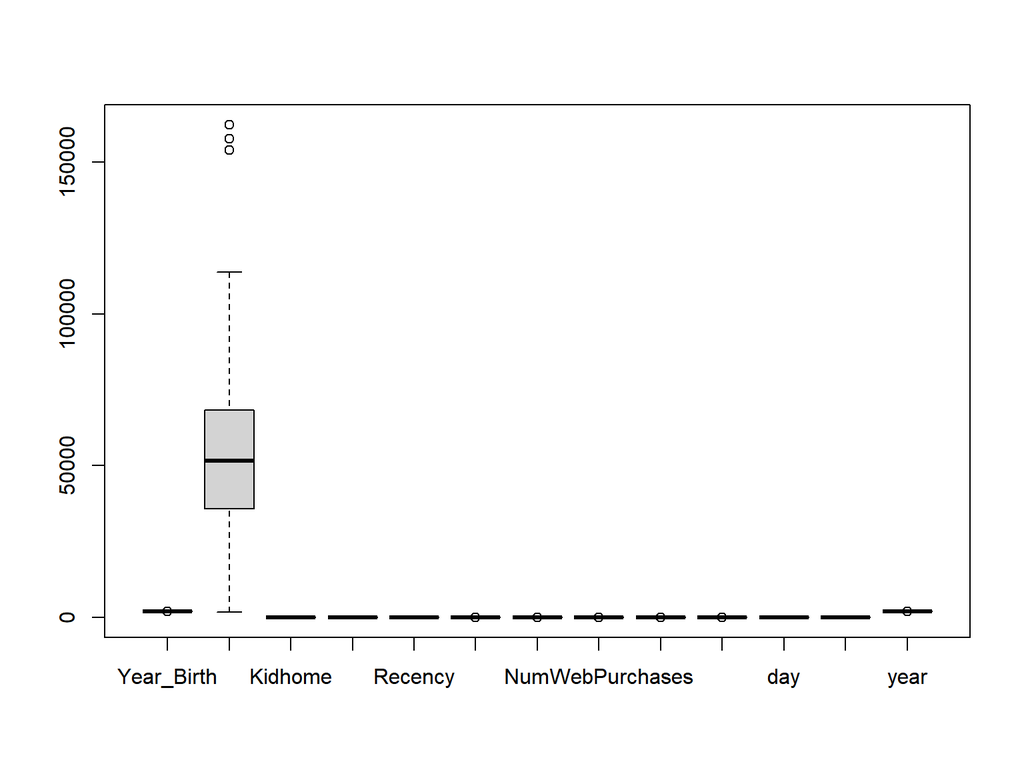

```r
# y variable 과 0,1로만 이루어진 변수를 제외한 numerical 변수에 대해서 정규화 전처리를 진행
scale_data <- subset(input_data, select = c(Year_Birth, Income, Kidhome, Teenhome, Recency, NumDealsPurchases,NumCatalogPurchases,
                                            NumWebPurchases, NumCatalogPurchases, NumWebVisitsMonth, day, month, year))
boxplot(scale_data)
```

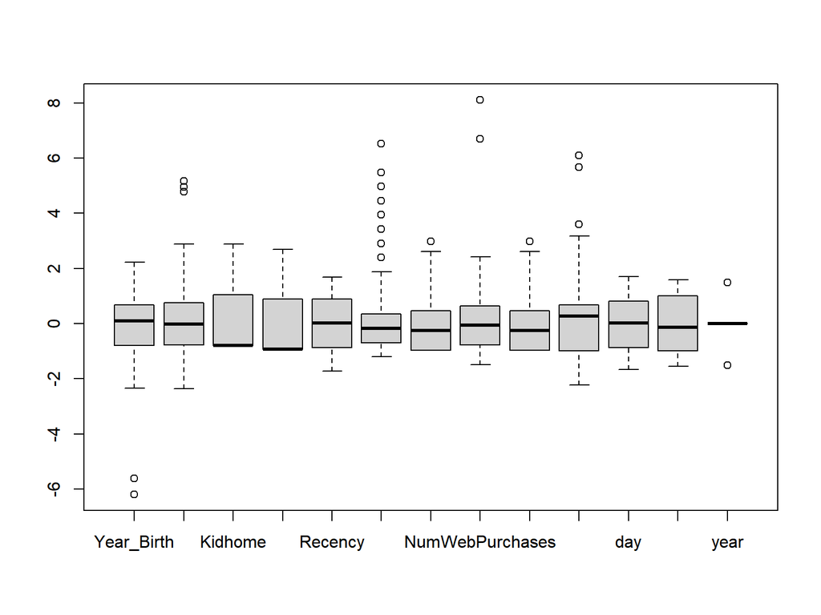

```r
# Standardization 표준화
scale <- caret::preProcess(scale_data, method = c("center", "scale"))
scale_data <- predict(scale, scale_data)
boxplot(scale_data)
```

```r
input_data <- input_data %>% select(-Year_Birth, -Income, -Kidhome, -Teenhome, -Recency, -NumDealsPurchases, -NumCatalogPurchases,
                                    -NumWebPurchases, -NumCatalogPurchases, -NumWebVisitsMonth, -day, -month, -year)
input_data <- cbind(input_data, scale_data)
input_data$target <- as.numeric(input_data$target)
rm(scale_data, scale)
```

Standardization 표준화는 중심극한 정리와 표준정규분포를 이용하여 각 변수들의 분포를 정규분포에 비슷하게 만들어준다. 해당 전처리 과정은 특히나 선형회귀, 로지스틱회귀에서 유용한 기법이다. 전처리 전, 후 과정을 Box plot을 통해 확인하였고 분포의 변화를 확인할 수 있다.

# 4 Modeling

분할한 데이터를 가지고 모든 변수들을 사용하는 모델과 Heuristic method의 feature selection을 적용한 모델들을 최종적으로 비교할 예정이다.  
모든 모델들은 동일한 전처리 과정을 거쳤고 같은 데이터를 이용하여 학습 및 테스트 하였으며 최종적으로 4가지의 모델이 구축되었다. 각 모델의 평가지표는 다음과 같이 요약할 수 있다. 자세항 사항은 코드와 함께 밑에서 확인할 수 있다.

**Simple Logistic Linear Regression**

- no feature selection, 모든 변수 활용
- target ~ all variable
- MSE 62815.47
- RMSE 250.6301
- MAE 168.5016
- adj R2 0.8229

**Backward Elimination Logistic Linear Regression**

- backward elimination
- target ~ AcceptedCmp1, 4, 5, NumStorePurchases, Income, Kidhome, Teenhome, Recency, NumCatalogPurchases, NumWebPurchases, NumWebVisitsMonth, day, month, year
- MSE 63506.62
- RMSE 252.0052
- MAE 169.133
- adj R2 0.8233

**Stepwise Selection Logistic Linear Regression**

- stepwise selection
- target ~ AcceptedCmp1, 4, 5, NumStorePurchases, Income, Kidhome, Teenhome, Recency, NumCatalogPurchases, NumWebPurchases, NumWebVisitsMonth, day, month, year
- MSE 63506.62
- RMSE 252.0052
- MAE 169.133
- adj R2 0.8233

## 4.1 Model 1 : No feature selection

가장 기본적인 전처리를 이정도로 진행하고 feature selection 작업을 하지 않은 채 모든 변수들을 학습하는 Multivariate Linear Regression model을 구축한다. 추후 feature selection 과정을 거친 모델과 다른 Heuristic method를 적용한 모델들을 비교할 예정이다.

```r
# Training
model_multi <- lm(target ~ ., data =input_data)
summary(model_multi)
```

```
##
## Call:
## lm(formula = target ~ ., data = input_data)
##
## Residuals:
##      Min       1Q   Median       3Q      Max
## -1454.42  -125.76   -21.76    89.20  1089.37
##
## Coefficients: (1 not defined because of singularities)
##                        Estimate Std. Error t value Pr(>|t|)
## (Intercept)            -352.811    259.942  -1.357  0.17498
## Education                 1.919      6.174   0.311  0.75605
## Marital_StatusAlone     805.753    316.039   2.550  0.01092 *
## Marital_StatusDivorced  741.238    259.990   2.851  0.00444 **
## Marital_StatusMarried   733.070    259.085   2.829  0.00475 **
## Marital_StatusSingle    734.685    259.117   2.835  0.00466 **
## Marital_StatusTogether  737.252    259.270   2.844  0.00455 **
## Marital_StatusWidow     694.089    262.321   2.646  0.00826 **
## Marital_StatusYOLO      600.495    363.881   1.650  0.09918 .
## AcceptedCmp3            -24.217     31.667  -0.765  0.44459
## AcceptedCmp4             87.968     31.439   2.798  0.00523 **
## AcceptedCmp5            312.077     36.123   8.639  < 2e-16 ***
## AcceptedCmp1            100.575     35.134   2.863  0.00428 **
## AcceptedCmp2            -41.816     68.061  -0.614  0.53909
## Complain                -28.660     81.443  -0.352  0.72498
## Response                  1.293     26.568   0.049  0.96119
## NumStorePurchases        33.207      3.438   9.659  < 2e-16 ***
## Year_Birth                9.320      8.775   1.062  0.28845
## Income                  191.308     14.752  12.968  < 2e-16 ***
## Kidhome                 -41.147     10.348  -3.976 7.47e-05 ***
## Teenhome                -65.979      9.540  -6.916 7.96e-12 ***
## Recency                  12.245      7.982   1.534  0.12529
## NumDealsPurchases         7.018     10.140   0.692  0.48898
## NumCatalogPurchases     208.733     12.197  17.114  < 2e-16 ***
## NumWebPurchases          59.694     10.475   5.699 1.56e-08 ***
## NumCatalogPurchases.1        NA         NA      NA       NA
## NumWebVisitsMonth        24.765     12.671   1.954  0.05091 .
## day                      18.963      7.693   2.465  0.01386 *
## month                   -14.396     10.021  -1.437  0.15113
## year                    -54.613     10.985  -4.971 7.73e-07 ***
## ---
## Signif. codes:  0 '***' 0.001 '**' 0.01 '*' 0.05 '.' 0.1 ' ' 1
##
## Residual standard error: 254 on 1079 degrees of freedom
## Multiple R-squared:  0.8274, Adjusted R-squared:  0.8229
## F-statistic: 184.8 on 28 and 1079 DF,  p-value: < 2.2e-16
```

```r
# MSE, RMSE, MAE
mean(model_multi$residuals^2)
```

```
## [1] 62815.47
```

```r
sqrt(mean(model_multi$residuals^2))
```

```
## [1] 250.6301
```

```r
mae(input_data$target, predict(model_multi))
```

```
## [1] 168.5016
```

## 4.2 Model 2 : Forward Selection

변수를 하나씩 추가해가면서 중요 변수를 선택하는 방법으로 학습 모델을 구축하고 평가해보았다.

```r
# Training
model_fwd <- step(lm(target ~ 1, input_data),
                  direction = "forward", trace = 0,
                  scope = formula(model_multi))
summary(model_multi)
```

```
##
## Call:
## lm(formula = target ~ ., data = input_data)
##
## Residuals:
##      Min       1Q   Median       3Q      Max
## -1454.42  -125.76   -21.76    89.20  1089.37
##
## Coefficients: (1 not defined because of singularities)
##                        Estimate Std. Error t value Pr(>|t|)
## (Intercept)            -352.811    259.942  -1.357  0.17498
## Education                 1.919      6.174   0.311  0.75605
## Marital_StatusAlone     805.753    316.039   2.550  0.01092 *
## Marital_StatusDivorced  741.238    259.990   2.851  0.00444 **
## Marital_StatusMarried   733.070    259.085   2.829  0.00475 **
## Marital_StatusSingle    734.685    259.117   2.835  0.00466 **
## Marital_StatusTogether  737.252    259.270   2.844  0.00455 **
## Marital_StatusWidow     694.089    262.321   2.646  0.00826 **
## Marital_StatusYOLO      600.495    363.881   1.650  0.09918 .
## AcceptedCmp3            -24.217     31.667  -0.765  0.44459
## AcceptedCmp4             87.968     31.439   2.798  0.00523 **
## AcceptedCmp5            312.077     36.123   8.639  < 2e-16 ***
## AcceptedCmp1            100.575     35.134   2.863  0.00428 **
## AcceptedCmp2            -41.816     68.061  -0.614  0.53909
## Complain                -28.660     81.443  -0.352  0.72498
## Response                  1.293     26.568   0.049  0.96119
## NumStorePurchases        33.207      3.438   9.659  < 2e-16 ***
## Year_Birth                9.320      8.775   1.062  0.28845
## Income                  191.308     14.752  12.968  < 2e-16 ***
## Kidhome                 -41.147     10.348  -3.976 7.47e-05 ***
## Teenhome                -65.979      9.540  -6.916 7.96e-12 ***
## Recency                  12.245      7.982   1.534  0.12529
## NumDealsPurchases         7.018     10.140   0.692  0.48898
## NumCatalogPurchases     208.733     12.197  17.114  < 2e-16 ***
## NumWebPurchases          59.694     10.475   5.699 1.56e-08 ***
## NumCatalogPurchases.1        NA         NA      NA       NA
## NumWebVisitsMonth        24.765     12.671   1.954  0.05091 .
## day                      18.963      7.693   2.465  0.01386 *
## month                   -14.396     10.021  -1.437  0.15113
## year                    -54.613     10.985  -4.971 7.73e-07 ***
## ---
## Signif. codes:  0 '***' 0.001 '**' 0.01 '*' 0.05 '.' 0.1 ' ' 1
##
## Residual standard error: 254 on 1079 degrees of freedom
## Multiple R-squared:  0.8274, Adjusted R-squared:  0.8229
## F-statistic: 184.8 on 28 and 1079 DF,  p-value: < 2.2e-16
```

```r
# MSE, RMSE, MAE
mean(model_fwd$residuals^2)
```

```
## [1] 63506.62
```

```r
sqrt(mean(model_fwd$residuals^2))
```

```
## [1] 252.0052
```

```r
mae(input_data$target, predict(model_fwd))
```

```
## [1] 169.133
```

## 4.3 Model 3 : Backward Elimination

유의미하지 않은 변수를 하나씩 제거해가면서 중요 변수를 선택하는 방법으로 학습 모델을 구축하고 평가해보았다.

```r
# Training
model_bwd <- step(lm(target ~ ., input_data),
                  direction = "backward", trace = 0,
                  scope = list(lower=target ~ 1, upper = formula(model_multi)))
summary(model_bwd)
```

```
##
## Call:
## lm(formula = target ~ AcceptedCmp4 + AcceptedCmp5 + AcceptedCmp1 +
##     NumStorePurchases + Income + Kidhome + Teenhome + Recency +
##     NumCatalogPurchases + NumWebPurchases + NumWebVisitsMonth +
##     day + month + year, data = input_data)
##
## Residuals:
##      Min       1Q   Median       3Q      Max
## -1440.80  -122.19   -22.88    87.74  1115.94
##
## Coefficients:
##                     Estimate Std. Error t value Pr(>|t|)
## (Intercept)          379.380     21.186  17.907  < 2e-16 ***
## AcceptedCmp4          87.947     29.885   2.943 0.003321 **
## AcceptedCmp5         301.502     35.067   8.598  < 2e-16 ***
## AcceptedCmp1          87.469     34.275   2.552 0.010847 *
## NumStorePurchases     34.280      3.270  10.485  < 2e-16 ***
## Income               191.830     14.514  13.217  < 2e-16 ***
## Kidhome              -36.695      9.641  -3.806 0.000149 ***
## Teenhome             -67.542      8.276  -8.161 9.05e-16 ***
## Recency               12.006      7.705   1.558 0.119477
## NumCatalogPurchases  205.652     11.784  17.452  < 2e-16 ***
## NumWebPurchases       61.595     10.204   6.037 2.15e-09 ***
## NumWebVisitsMonth     26.567     12.204   2.177 0.029693 *
## day                   18.213      7.649   2.381 0.017426 *
## month                -15.462      9.868  -1.567 0.117436
## year                 -54.301     10.670  -5.089 4.23e-07 ***
## ---
## Signif. codes:  0 '***' 0.001 '**' 0.01 '*' 0.05 '.' 0.1 ' ' 1
##
## Residual standard error: 253.7 on 1093 degrees of freedom
## Multiple R-squared:  0.8255, Adjusted R-squared:  0.8233
## F-statistic: 369.4 on 14 and 1093 DF,  p-value: < 2.2e-16
```

```r
# MSE, RMSE, MAE
mean(model_bwd$residuals^2)
```

```
## [1] 63506.62
```

```r
sqrt(mean(model_bwd$residuals^2))
```

```
## [1] 252.0052
```

```r
mae(input_data$target, predict(model_bwd))
```

```
## [1] 169.133
```

## 4.4 Model 4 : Stepwise Selection

앞선 forward selection 과 backward elimination 방법을 번갈아가면서 수행하는 방법으로 학습 모델을 구축하고 평가해보았다.

```r
# Training
model_step <- step(lm(target ~ ., input_data),
                   direction = "both", trace = 0,
                  scope = list(lower=target ~ 1, upper = formula(model_multi)))
summary(model_step)
```

```
##
## Call:
## lm(formula = target ~ AcceptedCmp4 + AcceptedCmp5 + AcceptedCmp1 +
##     NumStorePurchases + Income + Kidhome + Teenhome + Recency +
##     NumCatalogPurchases + NumWebPurchases + NumWebVisitsMonth +
##     day + month + year, data = input_data)
##
## Residuals:
##      Min       1Q   Median       3Q      Max
## -1440.80  -122.19   -22.88    87.74  1115.94
##
## Coefficients:
##                     Estimate Std. Error t value Pr(>|t|)
## (Intercept)          379.380     21.186  17.907  < 2e-16 ***
## AcceptedCmp4          87.947     29.885   2.943 0.003321 **
## AcceptedCmp5         301.502     35.067   8.598  < 2e-16 ***
## AcceptedCmp1          87.469     34.275   2.552 0.010847 *
## NumStorePurchases     34.280      3.270  10.485  < 2e-16 ***
## Income               191.830     14.514  13.217  < 2e-16 ***
## Kidhome              -36.695      9.641  -3.806 0.000149 ***
## Teenhome             -67.542      8.276  -8.161 9.05e-16 ***
## Recency               12.006      7.705   1.558 0.119477
## NumCatalogPurchases  205.652     11.784  17.452  < 2e-16 ***
## NumWebPurchases       61.595     10.204   6.037 2.15e-09 ***
## NumWebVisitsMonth     26.567     12.204   2.177 0.029693 *
## day                   18.213      7.649   2.381 0.017426 *
## month                -15.462      9.868  -1.567 0.117436
## year                 -54.301     10.670  -5.089 4.23e-07 ***
## ---
## Signif. codes:  0 '***' 0.001 '**' 0.01 '*' 0.05 '.' 0.1 ' ' 1
##
## Residual standard error: 253.7 on 1093 degrees of freedom
## Multiple R-squared:  0.8255, Adjusted R-squared:  0.8233
## F-statistic: 369.4 on 14 and 1093 DF,  p-value: < 2.2e-16
```

```r
# MSE, RMSE, MAE
mean(model_step$residuals^2)
```

```
## [1] 63506.62
```

```r
sqrt(mean(model_step$residuals^2))
```

```
## [1] 252.0052
```

```r
mae(input_data$target, predict(model_step))
```

```
## [1] 169.133
```

# 5 Evaluation

## 5.1 ANOVA

다중 선형 회귀 모델간의 비교를 위해서 ANOVA 진행하여 분산의 차이가 있는지 가설 검정을 진행하였다. 여기서 평균을 비교하지 않고 분산을 비교한 이유는 평균이 아니라 얼마나 퍼져있는지 보는게 더 중요하기 때문이다.

```r
anova(model_multi, model_fwd)
```

```
## Analysis of Variance Table
##
## Model 1: target ~ Education + Marital_Status + AcceptedCmp3 + AcceptedCmp4 +
##     AcceptedCmp5 + AcceptedCmp1 + AcceptedCmp2 + Complain + Response +
##     NumStorePurchases + Year_Birth + Income + Kidhome + Teenhome +
##     Recency + NumDealsPurchases + NumCatalogPurchases + NumWebPurchases +
##     NumCatalogPurchases.1 + NumWebVisitsMonth + day + month +
##     year
## Model 2: target ~ NumCatalogPurchases + Income + NumStorePurchases + AcceptedCmp5 +
##     NumWebPurchases + Teenhome + year + AcceptedCmp4 + Kidhome +
##     AcceptedCmp1 + NumWebVisitsMonth + day + month + Recency
##   Res.Df      RSS  Df Sum of Sq     F Pr(>F)
## 1   1079 69599540
## 2   1093 70365337 -14   -765797 0.848 0.6165
```

```r
anova(model_multi, model_bwd)
```

```
## Analysis of Variance Table
##
## Model 1: target ~ Education + Marital_Status + AcceptedCmp3 + AcceptedCmp4 +
##     AcceptedCmp5 + AcceptedCmp1 + AcceptedCmp2 + Complain + Response +
##     NumStorePurchases + Year_Birth + Income + Kidhome + Teenhome +
##     Recency + NumDealsPurchases + NumCatalogPurchases + NumWebPurchases +
##     NumCatalogPurchases.1 + NumWebVisitsMonth + day + month +
##     year
## Model 2: target ~ AcceptedCmp4 + AcceptedCmp5 + AcceptedCmp1 + NumStorePurchases +
##     Income + Kidhome + Teenhome + Recency + NumCatalogPurchases +
##     NumWebPurchases + NumWebVisitsMonth + day + month + year
##   Res.Df      RSS  Df Sum of Sq     F Pr(>F)
## 1   1079 69599540
## 2   1093 70365337 -14   -765797 0.848 0.6165
```

```r
anova(model_multi, model_step)
```

```
## Analysis of Variance Table
##
## Model 1: target ~ Education + Marital_Status + AcceptedCmp3 + AcceptedCmp4 +
##     AcceptedCmp5 + AcceptedCmp1 + AcceptedCmp2 + Complain + Response +
##     NumStorePurchases + Year_Birth + Income + Kidhome + Teenhome +
##     Recency + NumDealsPurchases + NumCatalogPurchases + NumWebPurchases +
##     NumCatalogPurchases.1 + NumWebVisitsMonth + day + month +
##     year
## Model 2: target ~ AcceptedCmp4 + AcceptedCmp5 + AcceptedCmp1 + NumStorePurchases +
##     Income + Kidhome + Teenhome + Recency + NumCatalogPurchases +
##     NumWebPurchases + NumWebVisitsMonth + day + month + year
##   Res.Df      RSS  Df Sum of Sq     F Pr(>F)
## 1   1079 69599540
## 2   1093 70365337 -14   -765797 0.848 0.6165
```

## 5.2 Plotting models

ANOVA 분석을 통해 feature selection을 거친 모델과 거치지 않은 모델 사이의 유의미한 성능 차이가 있지 않음을 알게되었으므로 기본 모델에 대해서 모형 진단 그래프를 시각화해보았다.

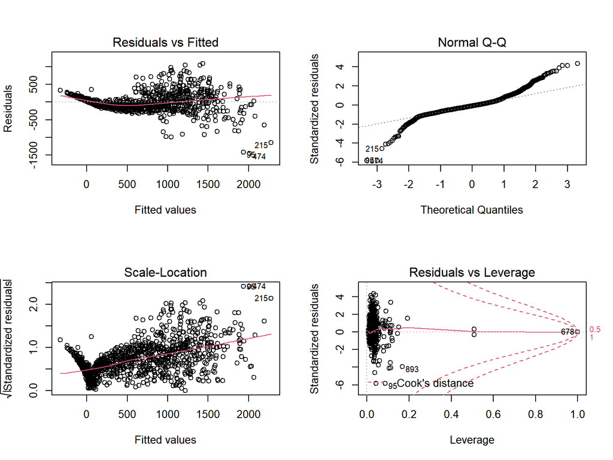

```r
par(mfrow = c(2,2))
plot(model_multi)
```

- Residuals vs Fitted - 실제값과 예측값 사이의 산점도를 보여준다 - 선형 회귀에서는 잔차의 평균이 0이고 분산이 일정하다는 등분산성과 정규성을 보여야 한다 - 모델의 예측값이 높아질수록 오차가 커지는 것을 알 수 있다 - 그렇기에 오차의 분산또한 예측값이 높아질수록 커지면서 등분산성을 서서히 벗어나는 것을 알 수 있다 - Normal Q-Q - 잔차가 정규분포를 따르는지 확인할 수 있는 차트이다 - 양극단 값에 가까워질수록 오차의 정규성을 벗어나는 것으로 보여진다 - Scale-Location - 모델이 예측한 Y와 잔차간의 관계를 비교하는 차트이다 - 역시나 앞선 차트들과 마찬가지로 예측값이 커질수록 잔차또한 커지는 것을 알 수 있다 - 이는 즉 y값이 크게 예측된 관측치들에 대해서 더 큰 값으로 틀리고 있다라고 해석가능하다 - 앞선 3개의 그래프로부터 예측값이 커질수록 잔차가 커지는 것을 확인, 이는 모델에 의해 설명되지 않는 관측치 또는 이상치(outlier)가 있을것이라는 추론으로 이어진다 - Residuals vs Leverage - 독립변수 중 극단적으로 치우처져 있는 것을 확인하는 차트이다 - 극단값, 이상치를 걸러내는데 유의미하다

최종적으로 모델의 성능을 높이기 위해서는 데이터에 숨어있는 outlier를 제거하는 것이 중요할 것이라 추론된다. 또한 해당 데이터 셋에 한해서는 feature selection을 거친다고 해서 무조건적인 유의미한 성능 향상으로는 이어지지 않을 것이며, ANOVA 분석 결과 유의미한 차이가 보이지 않기 때문에 만약 일반화 성능을 좀 더 추구한다면 Backward Elimiantion 방법을 통해 변수 선택을 진행하는 것이 더 좋을 것이라고 여겨진다.

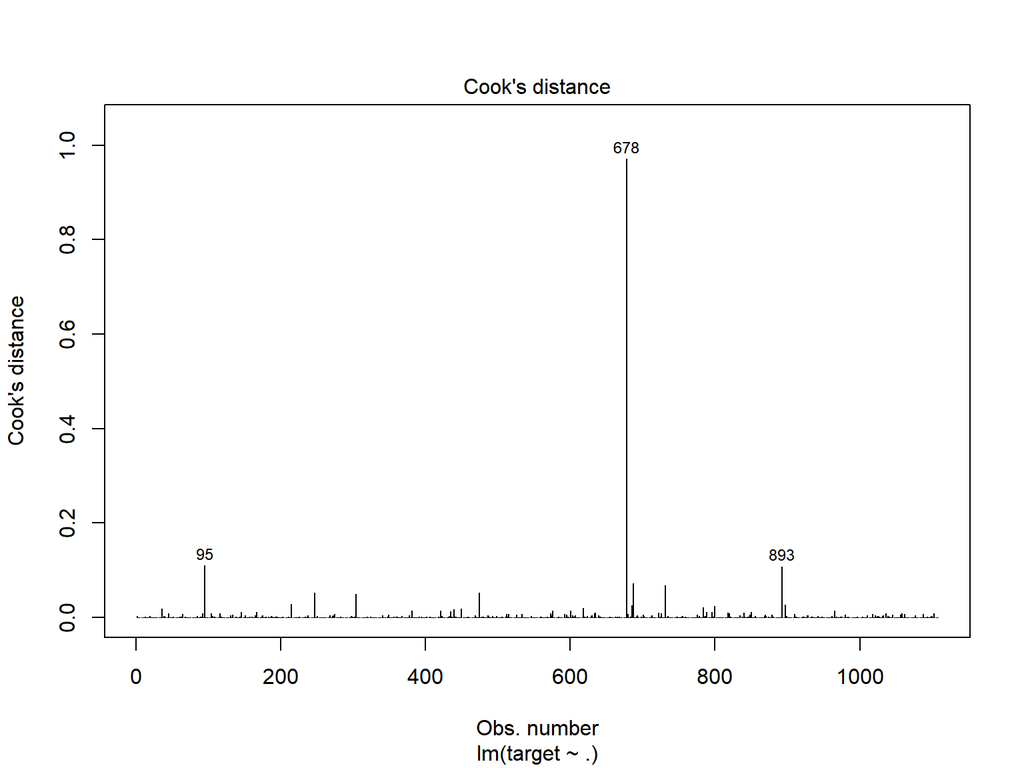

```r
# 눈에 띄는 극단값이 존재함을 Cook's distance를 통해 다시 한 번 확인 가능
plot(model_multi, which=4)
```